# โมเดลเชิงเส้นระดับลดหลั่น

สิวะโชติ ศรีสุทธิยากร  
กนิษฐ์ ศรีเคลือบ  
ภาควิชาวิจัยและจิตวิทยาการศึกษา คณะครุศาสตร์  
จุฬาลงกรณ์มหาวิทยาลัย  
6 May 2021

# เตรียมความพร้อมก่อนเรียน

เนื้อหาในวันนี้จะเรียนผ่านการทำกิจกรรม โดยใช้ชุดข้อมูลตัวอย่างคือชุดข้อมูล High School & Beyond สำรวจโดยศูนย์สถิติการศึกษาแห่งชาติ (National Center for Educational Statistics: NCES) ของสหรัฐอเมริกาในปี ค.ศ. 1982 ประกอบด้วยข้อมูลของนักเรียนจำนวน 7,185 คน จากโรงเรียนจำนวน 160 โรงเรียน ประกอบด้วยชุดข้อมูลระดับนักเรียน [hsb1.sav](https://drive.google.com/file/d/1AvFYXVcLxh3QqtKDBlpSUciUShuItBlV/view?usp=sharing) และชุดข้อมูลระดับโรงเรียน [hsb2.sav](https://drive.google.com/file/d/1RwMRt7eRqTs2eZ7LMfJoPRubutttDWys/view?usp=sharing)

ชุดข้อมูลในไฟล์ hsb2.sav ประกอบด้วยตัวแปรในระดับโรงเรียนได้แก่ (1) ขนาดโรงเรียน (size) ที่วัดจากจำนวนนักเรียนในโรงเรียน (2) ประเภทของโรงเรียน (sector) ที่มี 2 ประเภทได้แก่ 1 = โรงเรียนเครือคาทอริก และ 0 = โรงเรียนรัฐบาล (3) สัดส่วนนักเรียนที่เรียนอยู่ในสายวิชาการ (pracad) (4) บรรยากาศทางระเบียบวิจัย (disciplinary climate) (5) สัดส่วนของชนกลุ่มน้อย (himinty) โดย 1 = โรงเรียนที่มีชนกลุ่มน้อยมากกว่า 40% และ 0 = โรงเรียนที่มีชนกลุ่มน้อยน้อยกว่าหรือเท่ากับ 40% ของนักเรียนทั้งหมด และ (6) ค่าเฉลี่ยเศรษฐานะของนักเรียนในโรงเรียน (meanses)

## ติดตั้ง package ที่จำเป็น

การวิเคราะห์ HLM ด้วยโปรแกรม R จำเป็นต้อง download packages เพิ่มเติมดังนี้

```r
install.packages("lme4")
install.packages("lmerTest")

library(lme4)
library(lmerTest)
```

# **Hierarchical Linear Model (HLM)**

สืบเนื่องจากเนื้อหาในสัปดาห์ที่ผ่านมา นิสิตได้ทราบมโนทัศน์ และประเภทของข้อมูลพหุระดับที่มีหลากหลายประเภท ในสัปดาห์นี้จะลงรายละเอียดเกี่ยวกับโมเดลทางสถิติต่าง ๆ สำหรับการวิเคราะห์ข้อมูลพหุระดับแบบระดับลดหลั่น (hierarchical data) ด้วย โมเดลที่เรียกว่า **โมเดลเชิงเส้นแบบลดหลั่น (hierarchical linear model: HLM)** สารสนเทศที่ได้จากโมเดลดังกล่าวจะช่่วยให้นักวิจัยสามารถวิเคราะห์และอธิบายความผันแปรที่เกิดขึ้นในตัวแปรตามที่เกิดขึ้นจากตัวแปรที่อยู่ในระดับสูงกว่าได้

- [โมเดลพื้นฐานภายใต้กรอบ HLM](https://drive.google.com/file/d/1GpP-Pvc8QR17gIA4xAGGMug0d-q-DflN/view?usp=sharing)

โมเดล HLM ประกอบด้วยโมเดลย่อยหลายโมเดล ซึ่งครอบคลุมการวิเคราะห์ส่วนประกอบความแปรปรวนของตัวแปรตาม และการวิเคราะห์ความสัมพันธ์พหุระดับระหว่างตัวแปรตามกับตัวแปรอิสระ รายละเอียดของแต่ละโมเดลจะอธิบายผ่านการทำกิจกรรม 6 กิจกรรม ในหัวข้อต่อไป

## **One-Way ANOVA with random effect**

โมเดลการวิเคราะห์ความแปรปรวนทางเดียวแบบอิทธิพลสุ่มใช้สำหรับวิเคราะห์เพื่อเปรียบเทียบค่าเฉลี่ยระหว่างกลุ่มหรือระดับของปัจจัยที่ได้มาจากการสุ่ม จากชุดข้อมูล hsb1.sav ขอให้นิสิตดำเนินการดังต่อไปนี้

```r
# 1. importing data
library(foreign)
dat1<-read.spss("/Users/siwachoat/Library/Mobile Documents/com~apple~CloudDocs/เอกสารประกอบการสอน/2756714/dataset/week3/hsb1.sav", to.data.frame=T)
head(dat1)
```

```
##   schoolid minority female    ses mathach
## 1     1224        0      1 -1.528   5.876
## 2     1224        0      1 -0.588  19.708
## 3     1224        0      0 -0.528  20.349
## 4     1224        0      0 -0.668   8.781
## 5     1224        0      0 -0.158  17.898
## 6     1224        0      0  0.022   4.583
```

1. พิจารณาการแจกแจงของ `mathach`
2. พิจารณาการแจกแจงของ `mathach` จำแนกตามโรงเรียน

การแจกแจงของ `mathach` ในภาพรวมกับเมื่อจำแนกตามโรงเรียนมีความเหมือนหรือแตกต่างกันอย่างไร?

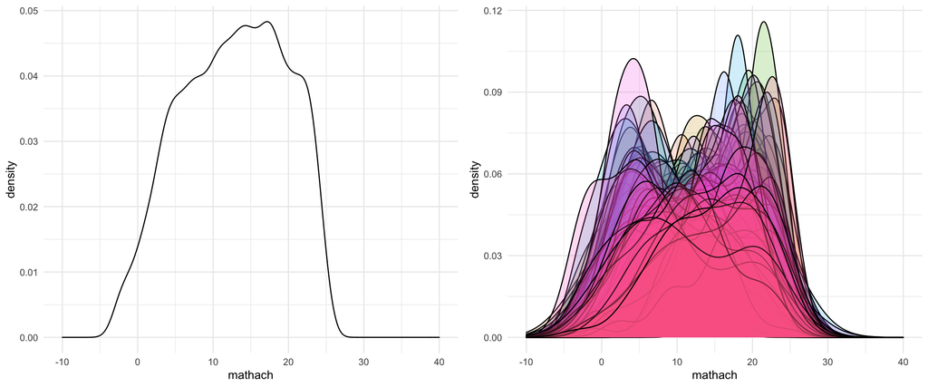

```r
library(dplyr)
library(ggplot2)
library(gridExtra)
dat1$schoolid<-factor(dat1$schoolid)
p1<-ggplot(dat1)+geom_density(aes(x=mathach),alpha=0.2)+xlim(-10,40)+theme_minimal()
p2<-ggplot(dat1)+geom_density(aes(x=mathach, fill=schoolid),alpha=0.2, show.legend = FALSE)+xlim(-10,40)+theme_minimal()
grid.arrange(p1,p2, ncol=2)
```

ลองพิจารณาด้วยค่าสถิติ

```r
dat1%>%summarise(mean=mean(mathach), sd=sd(mathach))
```

```
##       mean       sd
## 1 12.74785 6.878246
```

```r
dat1%>%group_by(schoolid)%>%summarise(mean=mean(mathach), sd=sd(mathach))
```

```
## # A tibble: 160 x 3
##    schoolid  mean    sd
##  * <fct>    <dbl> <dbl>
##  1 1224      9.72  7.59
##  2 1288     13.5   7.02
##  3 1296      7.64  5.35
##  4 1308     16.3   6.11
##  5 1317     13.2   5.46
##  6 1358     11.2   5.88
##  7 1374      9.73  8.36
##  8 1433     19.7   3.88
##  9 1436     18.1   4.55
## 10 1461     16.8   6.95
## # … with 150 more rows
```

```r
aggr<-dat1%>%group_by(schoolid)%>%summarise(mean=mean(mathach), sd=sd(mathach))
summary(aggr)
```

```
##     schoolid        mean             sd
##  1224   :  1   Min.   : 4.24   Min.   :3.541
##  1288   :  1   1st Qu.:10.47   1st Qu.:5.592
##  1296   :  1   Median :12.90   Median :6.320
##  1308   :  1   Mean   :12.62   Mean   :6.241
##  1317   :  1   3rd Qu.:14.65   3rd Qu.:6.863
##  1358   :  1   Max.   :19.72   Max.   :8.481
##  (Other):154
```

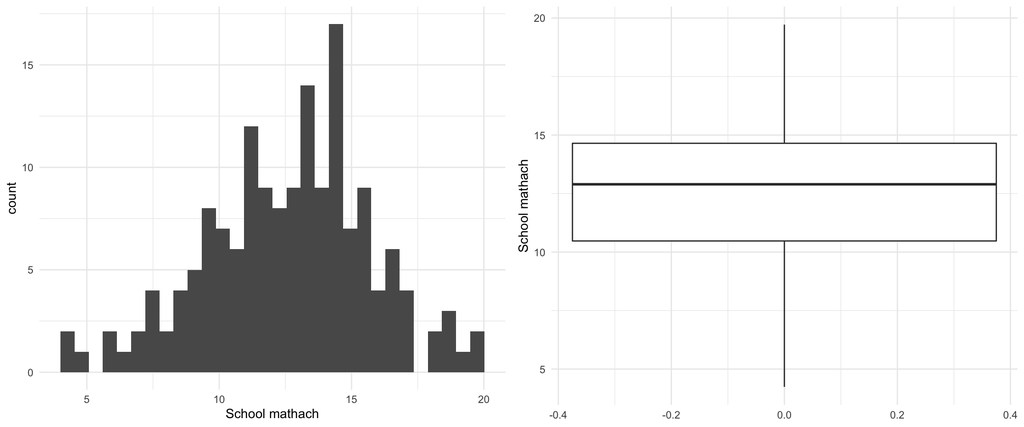

```r
p1<-aggr%>%ggplot()+geom_histogram(aes(x=mean))+xlab("School mathach")+theme_minimal()
p2<-aggr%>%ggplot()+geom_boxplot(aes(y=mean))+ylab("School mathach")+theme_minimal()
grid.arrange(p1,p2, ncol=2)
```

### **คำถามวิจัย**

คะแนน mathach ของนักเรียนในแต่ละโรงเรียนมีความแตกต่างกันหรือไม่?

### **โมเดลการวิเคราะห์**

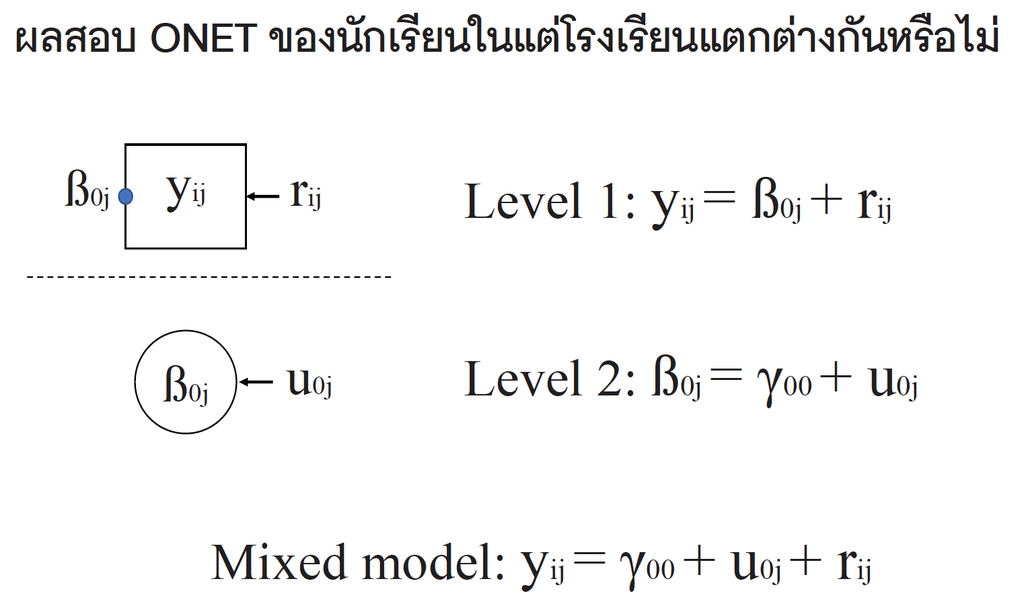

ในกรณีนี้โมเดลการวิเคราะห์มี 2 ระดับ ได้แก่โมเดลระดับนักเรียน และโมเดลระดับโรงเรียนดังนี้

**โมเดลระดับนักเรียน (student-level model)**

$mathach_{ij}=\beta_{0j}+r_{ij}$

**โมเดลระดับโรงเรียน (school-level model)**

$\beta_{0j}=\gamma_{00}+u_{0j}$

จากสมการทั้งสองสามารถนำมารวมกันเพื่อเขียนเป็น**โมเดลรวม (combined model)** ได้ดังนี้

$mathach_{ij}=\gamma_{00}+u_{0j}+r_{ij}$

เมื่อ $i = 1, 2, 3, ..., n_j$ และ $j = 1, 2, 3, ..., J$

จากสมการในโมเดลรวมข้างต้นจะเห็นว่ามีการระบุอิทธิพลที่มีต่อ `mathach` ของนักเรียน 2 ตัวได้แก่ อิทธิพลคงที่ (fixed effect) คือ $\gamma_{00}$ ที่เป็นค่าเฉลี่ยผลสัมฤทธิ์รวม (grand mean) และอิทธิพลสุ่ม (random effect) คือ $u_{0j}$ กับ $r_{ij}$ ที่เป็นความแตกต่างระหว่างโรงเรียน และระหว่างนักเรียนภายในโรงเรียนตามลำดับ โดยที่ $u_{0j} \sim N(0, \tau_{00})$ และ $r_{ij} \sim N(0,\sigma^2)$

**Note:** พารามิเตอร์ในโมเดลข้างต้นมีกี่ตัว อะไรบ้าง แต่ละตัวมีความหมายอย่างไร?

การประมาณค่าพารามิเตอร์ในโมเดลข้างต้นด้วยโปรแกรม R สามารถทำได้โดยใช้ใช้ฟังก์ชัน `lmer()` ซึ่งจะระบุโมเดลโดยอิงจากโมเดลรวม (combined model) จากค่าพารามิเตอร์ของหน่วยข้อมูลในระดับที่ 2 เท่านั้น ในกรณีข้างต้นจึงระบุเพียงพารามิเตอร์ fixed-effect ($\gamma_{00}$) และพารามิเตอร์ random-effect ($u_{0j}$) ดังนี้ `lmer(math~1+(1|schoolid))`

```r
#1. estimate the model parameters
null.model<-lmer(mathach~1+(1|schoolid),data=dat1)

#2. extract the output
summary(null.model)
```

```
## Linear mixed model fit by REML. t-tests use Satterthwaite's method [
## lmerModLmerTest]
## Formula: mathach ~ 1 + (1 | schoolid)
##    Data: dat1
##
## REML criterion at convergence: 47116.8
##
## Scaled residuals:
##     Min      1Q  Median      3Q     Max
## -3.0631 -0.7539  0.0267  0.7606  2.7426
##
## Random effects:
##  Groups   Name        Variance Std.Dev.
##  schoolid (Intercept)  8.614   2.935
##  Residual             39.148   6.257
## Number of obs: 7185, groups:  schoolid, 160
##
## Fixed effects:
##             Estimate Std. Error       df t value Pr(>|t|)
## (Intercept)  12.6370     0.2444 156.6473   51.71   <2e-16 ***
## ---
## Signif. codes:  0 '***' 0.001 '**' 0.01 '*' 0.05 '.' 0.1 ' ' 1
```

การวิเคราะห์ null model จะให้สารสนเทศที่สำคัญคือปริมาณความแปรปรวนในตัวแปรตามที่เกิดขึ้นอันเนื่องมาจากตัวแปร (ที่ไม่ได้สังเกตค่าในโมเดลนี้) ในแต่ละระดับ (ระดับนักเรียน/ระดับโรงเรียน) ผลการวิเคราะห์ข้างต้นจะเห็นว่า ความแปรปรวนระดับนักเรียนมีค่าเท่ากับ $\sigma^2 = 39.148$ และความแปรปรวนระดับโรงเรียนมีค่าเท่ากับ $\tau = 8.614$ ผลการวิเคราะห์นี้ทำให้สามารถประมาณค่าสถิติที่สำคัญตัวหนึ่งคือ สัมประสิทธิ์สหสัมพันธ์ภายในกลุ่ม (intraclass correlation: ICC) ดังนี้

$ICC = \frac{8.614}{8.614+39.148} = .1804$

ปัจจุบันการคำนวณ ICC ในข้างต้นสามารถทำได้โดยใช้ package-sjstats ดังนี้

```r
install.packages("sjstats")
```

```r
library(sjstats)
performance::icc(null.model)
```

```
## # Intraclass Correlation Coefficient
##
##      Adjusted ICC: 0.180
##   Conditional ICC: 0.180
```

นอกจากนี้ผู้วิเคราะห์ยังสามารถเรียกผลทดสอบนัยสำคัญของอิทธิพลสุ่มในโมเดลได้ด้วยฟังก์ชัน package-ranova() ดังนี้

```r
ranova(null.model)
```

```
## ANOVA-like table for random-effects: Single term deletions
##
## Model:
## mathach ~ (1 | schoolid)
##                npar logLik   AIC    LRT Df Pr(>Chisq)
## <none>            3 -23558 47123
## (1 | schoolid)    2 -24052 48107 986.12  1  < 2.2e-16 ***
## ---
## Signif. codes:  0 '***' 0.001 '**' 0.01 '*' 0.05 '.' 0.1 ' ' 1
```

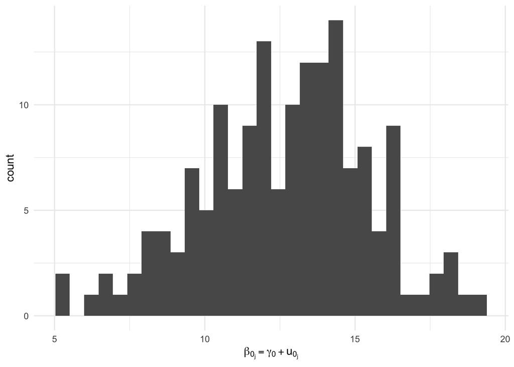

```r
intercept<-coef(null.model)
intercept<-intercept[1]
names(intercept$schoolid)<-"u0j"
intercept$schoolid%>%
      ggplot()+geom_histogram(aes(x=u0j))+
         xlab(expression(beta[0[j]]==gamma[00]+u[0[j]]))+
        theme_minimal()
```

### การวินิจฉัยความเหมาะสมของโมเดลการวิเคราะห์

```r
#calculate level-1 residuals
res1<-residuals(null.model)

#calculae level-2 residuals
res2<-dat1$mathach-12.6370-res1
```

**(1) normality**

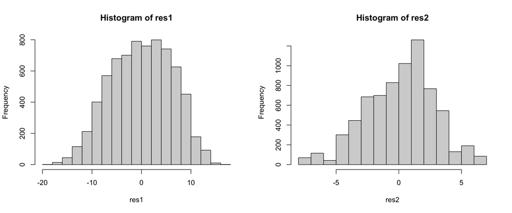

```r
par(mfrow=c(1,2))
hist(res1)
hist(res2)
```

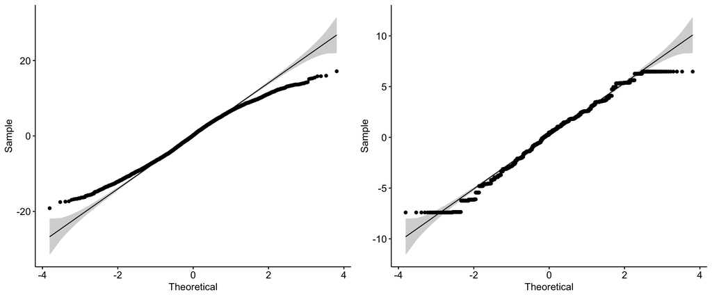

```r
library(ggpubr)
p1<-ggqqplot(res1)
p2<-ggqqplot(res2)
grid.arrange(p1,p2, ncol=2)
```

**(2) homogeneity of variances**

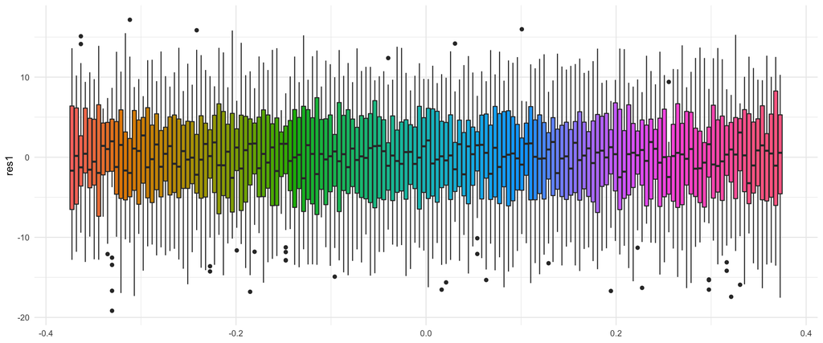

```r
temp<-dat1
temp$e2<-res1^2
temp$res1<-res1
temp$schoolid<-factor(temp$schoolid)
temp%>%ggplot()+geom_boxplot(aes(y=res1,fill=schoolid),show.legend=F)+theme_minimal()
```

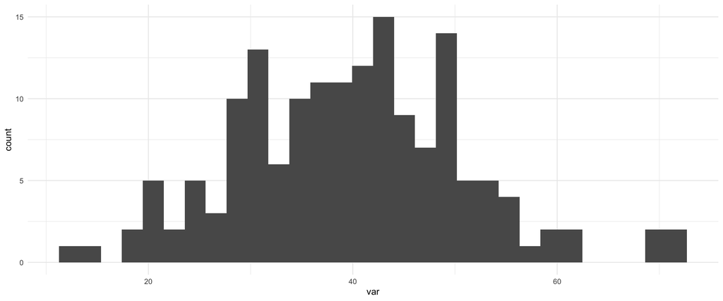

```r
temp%>%group_by(schoolid)%>%summarise(var=var(res1))%>%
      ggplot()+geom_histogram(aes(x=var))+theme_minimal()
```

```r
temp%>%group_by(schoolid)%>%summarise(var=var(res1))%>%summary()
```

```
##     schoolid        var
##  1224   :  1   Min.   :12.54
##  1288   :  1   1st Qu.:31.27
##  1296   :  1   Median :39.94
##  1308   :  1   Mean   :39.75
##  1317   :  1   3rd Qu.:47.10
##  1358   :  1   Max.   :71.93
##  (Other):154
```

```r
#log-determinant criterion
log(71.93)/log(12.54)
```

```
## [1] 1.690717
```

## **Means as Outcomes Regression Model**

จากผลการวิเคราะห์ใน nullmodel จะเห็นว่าสามารถแยกส่วนประกอบความแปรปรวนในผลสัมฤทธิ์ทางการเรียนวิชาคณิตศาสตร์ได้เป็นสองส่วนได้แก่ ความแปรปรวนระดับนักเรียน และความแปรปรวนในระดับโรงเรียน ซึ่งแสดงว่าผลสัมฤทธิ์ดังกล่าวมีความผันแปรไปตามโรงเรียนที่แตกต่างกันด้วย

ในการวิจัยบางงานอาจสนใจอธิบายความผันแปรของผลสัมฤทธิ์ในระดับโรงเรียนดังกล่าว โดยอาจหาตัวแปรอิสระในระดับโรงเรียนมาอธิบาย โมเดลการวิเคราะห์ในกรณีนี้จึงจะมีการเพิ่มตัวแปรอิสระในโมเดลระดับโรงเรียนเพื่ออธิบายความผันแปรในพารามิเตอร์ intercept เรียกโมเดลการวิเคราะห์นี้ว่า mean as outcome regression model หรือ โมเดลสัมประสิทธิ์จุดตัดแกนสุ่ม (random intercept model)

### **คำถามวิจัย**

เศรษฐานะของนักเรียนในระดับโรงเรียนส่งผลต่อคะแนนเฉลี่ยผลสัมฤทธิ์ทางการเรียนคณิตศาสตร์ของนักเรียนในระดับโรงเรียนหรือไม่่?

### **โมเดลการวิเคราะห์**

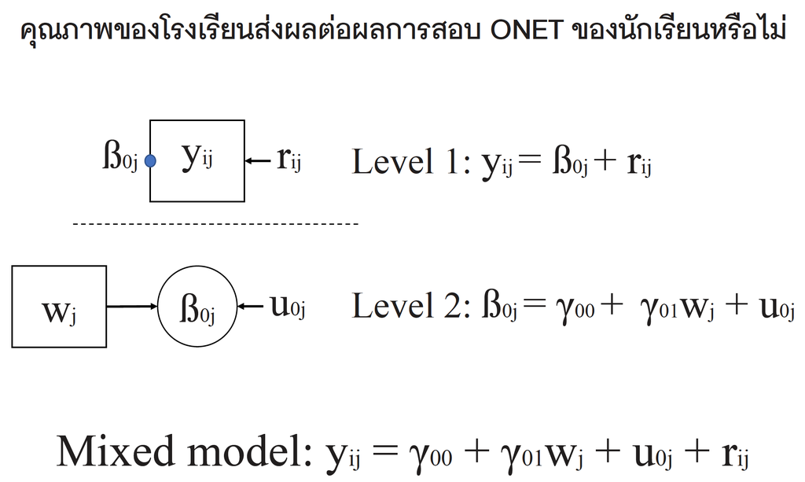

เนื่องจากโมเดลการวิเคราะห์นี้จำเป็นต้องใช้ข้อมูลของตัวแปรอิสระในระดับโรงเรียน คือ `meanses` มาเป็นตัวแปรอธิบายความผันแปรที่เกิดขึ้นในค่าเฉลี่ยผลสัมฤทธิ์ในระดับโรงเรียน การวิเคราะห์จึงจำเป็นต้องมีการเตรียมชุดข้อมูลให้พร้อมก่อนการวิเคราะห์ด้วยการรวมชุดข้อมูล hsb1.sav และ hsb2.sav เข้าด้วยกัน ในโปรแกรม R อาจใช้ฟังก์ชัน `merge()` ดังนี้

```r
# hsb1.sav
dat1<-read.spss("/Users/siwachoat/Library/Mobile Documents/com~apple~CloudDocs/เอกสารประกอบการสอน/2756714/dataset/week3/hsb1.sav", to.data.frame=T)
head(dat1)
```

```
##   schoolid minority female    ses mathach
## 1     1224        0      1 -1.528   5.876
## 2     1224        0      1 -0.588  19.708
## 3     1224        0      0 -0.528  20.349
## 4     1224        0      0 -0.668   8.781
## 5     1224        0      0 -0.158  17.898
## 6     1224        0      0  0.022   4.583
```

```r
# hsb2.sav
dat2<-read.spss("/Users/siwachoat/Library/Mobile Documents/com~apple~CloudDocs/เอกสารประกอบการสอน/2756714/dataset/week3/hsb2.sav", to.data.frame=T)
head(dat2)
```

```
##   schoolid size sector pracad disclim himnty meanses
## 1     1224  842      0   0.35   1.597      0  -0.428
## 2     1288 1855      0   0.27   0.174      0   0.128
## 3     1296 1719      0   0.32  -0.137      1  -0.420
## 4     1308  716      1   0.96  -0.622      0   0.534
## 5     1317  455      1   0.95  -1.694      1   0.351
## 6     1358 1430      0   0.25   1.535      0  -0.014
```

```r
# merge dataset
dat<-merge(dat2,dat1,by="schoolid")
str(dat)
```

```
## 'data.frame':    7185 obs. of  11 variables:
##  $ schoolid: num  1224 1224 1224 1224 1224 ...
##  $ size    : num  842 842 842 842 842 842 842 842 842 842 ...
##  $ sector  : num  0 0 0 0 0 0 0 0 0 0 ...
##  $ pracad  : num  0.35 0.35 0.35 0.35 0.35 0.35 0.35 0.35 0.35 0.35 ...
##  $ disclim : num  1.6 1.6 1.6 1.6 1.6 ...
##  $ himnty  : num  0 0 0 0 0 0 0 0 0 0 ...
##  $ meanses : num  -0.428 -0.428 -0.428 -0.428 -0.428 -0.428 -0.428 -0.428 -0.428 -0.428 ...
##  $ minority: num  0 0 0 0 0 0 0 0 0 0 ...
##  $ female  : num  1 1 0 0 0 0 1 0 1 0 ...
##  $ ses     : num  -1.528 -0.588 -0.528 -0.668 -0.158 ...
##  $ mathach : num  5.88 19.71 20.35 8.78 17.9 ...
```

เมื่อยุบรวมชุดข้อมูลแล้ว สามารถประมาณค่าพารามิเตอร์ในโมเดลโดยกำหนดโมเดลในฟังก์ชัน `lmer()` ด้วยหลักภาษาเหมือนเดิมดังนี้

```r
mean.model<-lmer(mathach~meanses+(1|schoolid),data=dat)
summary(mean.model)
```

```
## Linear mixed model fit by REML. t-tests use Satterthwaite's method [
## lmerModLmerTest]
## Formula: mathach ~ meanses + (1 | schoolid)
##    Data: dat
##
## REML criterion at convergence: 46961.3
##
## Scaled residuals:
##      Min       1Q   Median       3Q      Max
## -3.13480 -0.75256  0.02409  0.76773  2.78501
##
## Random effects:
##  Groups   Name        Variance Std.Dev.
##  schoolid (Intercept)  2.639   1.624
##  Residual             39.157   6.258
## Number of obs: 7185, groups:  schoolid, 160
##
## Fixed effects:
##             Estimate Std. Error       df t value Pr(>|t|)
## (Intercept)  12.6494     0.1493 153.7425   84.74   <2e-16 ***
## meanses       5.8635     0.3615 153.4067   16.22   <2e-16 ***
## ---
## Signif. codes:  0 '***' 0.001 '**' 0.01 '*' 0.05 '.' 0.1 ' ' 1
##
## Correlation of Fixed Effects:
##         (Intr)
## meanses -0.004
```

ผลการวิเคราะห์ข้างต้นหมายความว่าอย่างไร??

## **One-Way ANCOVA with random effect**

ผลการวิเคราะห์ null model เราทราบแล้วว่าความแปรปรวนระหว่างกลุ่ม (ระหว่างโรงเรียน) มีนัยสำคัญทางสถิติ ซึ่งให้ข้อสรุปว่า ผลสัมฤทธิ์ทางการเรียนของนักเรียนในแต่ละโรงเรียนมีค่าเฉลี่ยที่แตกต่างกัน อย่างไรก็ตามอาจมีข้อสงสัยว่าความแตกต่างที่เกิดขึ้นนั้นไม่ได้เป็นเพราะการบริหารจัดการของโรงเรียนแต่เพียงอย่างเดียว แต่อาจะเป็นเพราะพื้นฐานทางบ้านของผู้เรียนในแต่ละโรงเรียนไม่เท่าเทียมกันด้วย เพื่อพิสูจน์ข้อสงสัยนี้ผู้วิจัยจึงนำตัวแปรเศรษฐานะ (ses) ของผู้เรียนมาเป็นตัวแปรควบคุมในโมเดล และทำการวิเคราะห์โดยใช้เทคนิคการวิเคราะห์ความแปรปรวนร่วม ดังนี้

### **คำถามวิจัย**

เมื่อมีการควบคุมปัจจัยด้านเศรษฐานะให้คงที่ ผลสัมฤทธิ์ของนักเรียนในระดับโรงเรียนมีความแตกต่างกันหรือไม่ อย่างไร?

### **โมเดลการวิเคราะห์**

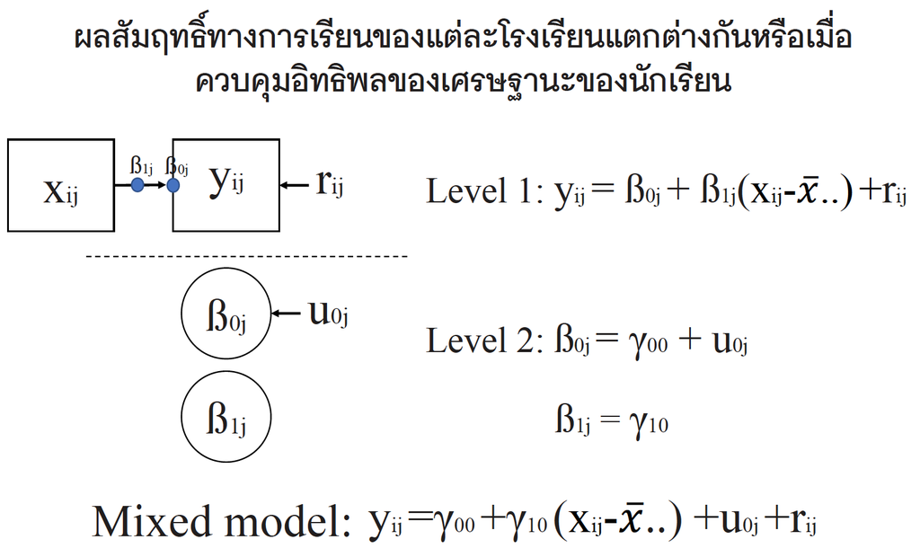

เพื่อให้ค่าจุดตัดแกนมีความหมายและสามารถแปลความได้อย่างสมบูรณ์ การวิเคราะห์ความแปรปรวนร่วมจึงมักมีการ centering ตัวแปรควบคุมก่อนการวิเคราะห์ ดังนี้

```r
#centering ses by groupmean
ses.cen<-dat$ses-dat$meanses
dat$ses.cen<-ses.cen
```

การประมาณค่าพารามิเตอร์ในโมเดลการวิเคราะห์สามารถทำได้ดังนี้

```r
ancova.model<-lmer(mathach~ses.cen+(1|schoolid),data=dat,REML=F)
summary(ancova.model)
```

```
## Linear mixed model fit by maximum likelihood . t-tests use Satterthwaite's
##   method [lmerModLmerTest]
## Formula: mathach ~ ses.cen + (1 | schoolid)
##    Data: dat
##
##      AIC      BIC   logLik deviance df.resid
##  46728.4  46755.9 -23360.2  46720.4     7181
##
## Scaled residuals:
##      Min       1Q   Median       3Q      Max
## -3.09692 -0.73196  0.01945  0.75739  2.91423
##
## Random effects:
##  Groups   Name        Variance Std.Dev.
##  schoolid (Intercept)  8.612   2.935
##  Residual             37.005   6.083
## Number of obs: 7185, groups:  schoolid, 160
##
## Fixed effects:
##              Estimate Std. Error        df t value Pr(>|t|)
## (Intercept)   12.6494     0.2437  157.7181   51.90   <2e-16 ***
## ses.cen        2.1912     0.1086 7023.0025   20.17   <2e-16 ***
## ---
## Signif. codes:  0 '***' 0.001 '**' 0.01 '*' 0.05 '.' 0.1 ' ' 1
##
## Correlation of Fixed Effects:
##         (Intr)
## ses.cen 0.003
```

โมเดล random effect ANCOVA มีลักษณะเกือบเหมือนกับโมเดล ANCOVA แบบปกติ ต่างกันเพียงอิทธิพลของตัวแปรอิสระแบบจัดประเภทที่มีต่อตัวแปรตามเป็นอิทธิพลแบบสุ่ม ดังนั้นข้อตกลงเบื้องต้นของโมเดล random effect ANCOVA จึงเหมือนกับโมเดล ANCOVA แบบปกติทุกประการ ข้อตกลงเบื้องต้นที่สำคัญคือ homogeneity of regression slope ที่กำหนดให้สัมประสิทธิ์ความชันของตัวแปร covariate มีค่าเท่ากันในแต่ละกลุ่มหรือระดับของปัจจัย

นิสิตคิดว่า assumption ดังกล่าวเป็นจริงในข้อมูลชุดนี้หรือไม่? จะตรวจสอบได้อย่างไร? และหากไม่เป็นจริงจะแก้ปัญหาอย่างไร?

## **Random-coefficient Regression model**

โมเดลนี้มีลักษณะเฉพาะคือมีการกำหนดให้สัมประสิทธิ์ความถดถอยทั้งหมดของโมเดลเป็นอิทธิพลแบบสุ่ม ซึ่งทำให้จุดตัดแกนและอิทธิพลของตัวแปรอิสระที่มีต่อตัวแปรตามมีความแตกต่างกันอย่างสุ่มระหว่างกลุ่ม

### **คำถามวิจัย**

- อิทธิพลของ ses ที่มีต่อ mathach มีความแตกต่างกันระหว่างโรงเรียนหรือไม่
- เมื่อควบคุมอิทธิพลสุ่มของ ses ให้คงที่ แล้ว mathach ในระดับโรงเรียนมีความแตกต่างกันหรือไม่
- คุณภาพและความเหลื่อมล้ำทางการศึกษาของแต่ละโรงเรียนเป็นอย่างไร

### **โมเดลการวิเคราะห์**

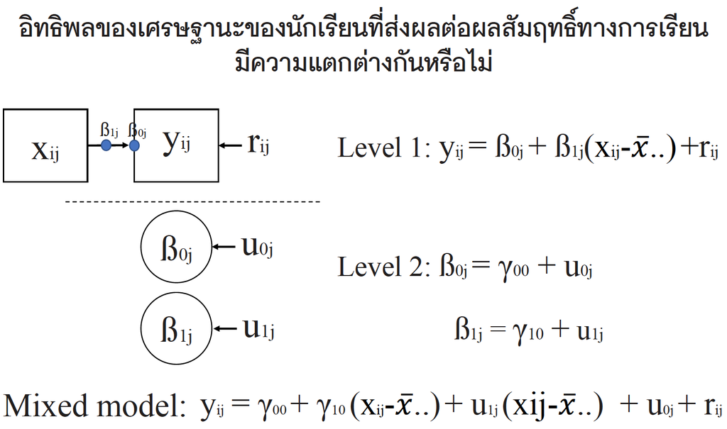

การกำหนดโมเดลการวิเคราะห์ในฟังก์ชัน `lmer()` สามารถทำได้ในทำนองเดียวกัน ดังนี้

```r
random.coef<-lmer(mathach~ses.cen+(1+ses.cen|schoolid), data=dat)
summary(random.coef)
```

```
## Linear mixed model fit by REML. t-tests use Satterthwaite's method [
## lmerModLmerTest]
## Formula: mathach ~ ses.cen + (1 + ses.cen | schoolid)
##    Data: dat
##
## REML criterion at convergence: 46714.2
##
## Scaled residuals:
##      Min       1Q   Median       3Q      Max
## -3.09680 -0.73194  0.01858  0.75388  2.89928
##
## Random effects:
##  Groups   Name        Variance Std.Dev. Corr
##  schoolid (Intercept)  8.682   2.9465
##           ses.cen      0.694   0.8331   0.02
##  Residual             36.700   6.0581
## Number of obs: 7185, groups:  schoolid, 160
##
## Fixed effects:
##             Estimate Std. Error       df t value Pr(>|t|)
## (Intercept)  12.6493     0.2445 156.7391   51.73   <2e-16 ***
## ses.cen       2.1932     0.1283 155.2180   17.10   <2e-16 ***
## ---
## Signif. codes:  0 '***' 0.001 '**' 0.01 '*' 0.05 '.' 0.1 ' ' 1
##
## Correlation of Fixed Effects:
##         (Intr)
## ses.cen 0.012
```

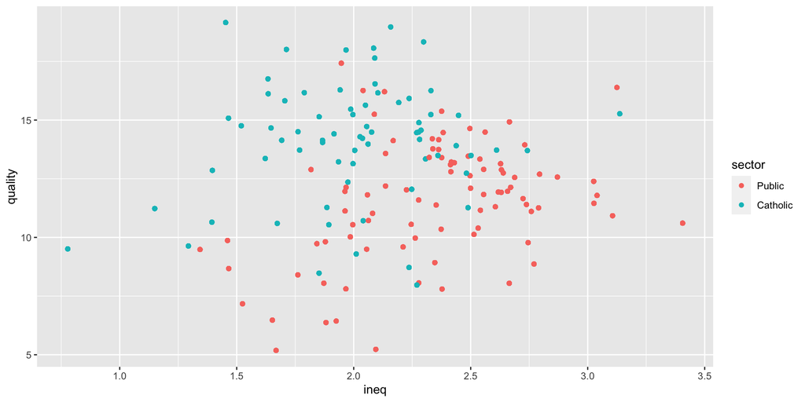

```r
coef<-coef(random.coef)
coef<-coef$schoolid
names(coef)<-c("quality","ineq")
coef$schoolid<-rownames(coef)
sector<-dat%>%select(schoolid, sector)
coef<-merge(coef,sector, by="schoolid")
coef$sector<-factor(coef$sector, labels=c("Public","Catholic"))
coef%>%ggplot()+geom_point(aes(x=ineq, y=quality,col=sector))
```

## **Intercepts and slopes as outcomes model**

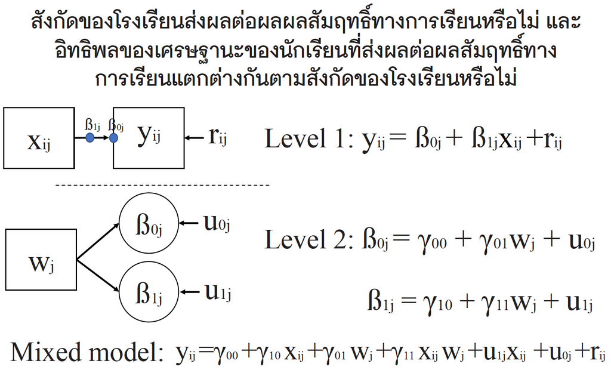

[figure not shown]

## **Non-randomly varying slopes**

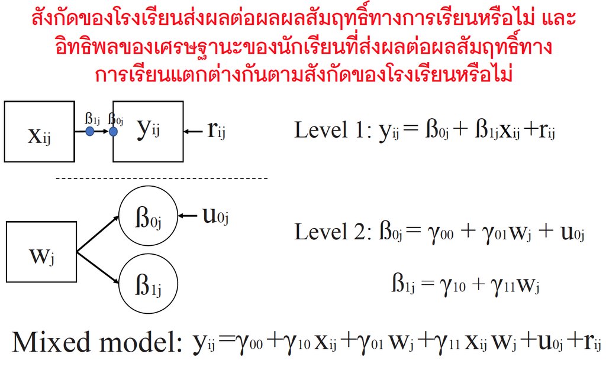

```r
nonrandom.model<-lmer(mathach~ses+sector+ses*sector+(1|schoolid),data=dat)
summary(nonrandom.model)
```

```
## Linear mixed model fit by REML. t-tests use Satterthwaite's method [
## lmerModLmerTest]
## Formula: mathach ~ ses + sector + ses * sector + (1 | schoolid)
##    Data: dat
##
## REML criterion at convergence: 46574.2
##
## Scaled residuals:
##      Min       1Q   Median       3Q      Max
## -3.07709 -0.72532  0.01753  0.76025  3.02224
##
## Random effects:
##  Groups   Name        Variance Std.Dev.
##  schoolid (Intercept)  3.694   1.922
##  Residual             36.840   6.070
## Number of obs: 7185, groups:  schoolid, 160
##
## Fixed effects:
##              Estimate Std. Error        df t value Pr(>|t|)
## (Intercept)   11.7980     0.2285  155.1103  51.629  < 2e-16 ***
## ses            2.9512     0.1406 6843.1069  20.989  < 2e-16 ***
## sector         2.1382     0.3413  148.0143   6.264 3.87e-09 ***
## ses:sector    -1.3128     0.2120 6719.6983  -6.193 6.26e-10 ***
## ---
## Signif. codes:  0 '***' 0.001 '**' 0.01 '*' 0.05 '.' 0.1 ' ' 1
##
## Correlation of Fixed Effects:
##            (Intr) ses    sector
## ses         0.084
## sector     -0.669 -0.057
## ses:sector -0.056 -0.663 -0.017
```